# Risk Factor Analysis

## Outcome Variable

**Outcome Variable:** y_rate_haz

## Predictor Variables

**Intervention Variable:** cleanck

**Adjustment Set:**

- arm
- sex
- W_mage
- meducyrs
- feducyrs
- hhwealth_quart
- W_nrooms
- W_nhh
- W_nchldlt5
- trth2o
- impfloor
- delta_meducyrs
- delta_feducyrs
- delta_hhwealth_quart
- delta_W_nrooms
- delta_W_nhh
- delta_W_nchldlt5
- delta_trth2o
- delta_impfloor

## Stratifying Variables

The analysis was stratified on these variable(s):

- agecat
- studyid
- country

## Data Summary

| agecat | studyid | country | cleanck | n_cell | n | outcome_variable |
| --- | --- | --- | --- | --- | --- | --- |
| 0-3 months | ki0047075b-MAL-ED | PERU | 1 | 1 | 1 | y_rate_haz |
| 0-3 months | ki0047075b-MAL-ED | PERU | 0 | 0 | 1 | y_rate_haz |
| 0-3 months | ki0047075b-MAL-ED | SOUTH AFRICA | 1 | 1 | 2 | y_rate_haz |
| 0-3 months | ki0047075b-MAL-ED | SOUTH AFRICA | 0 | 1 | 2 | y_rate_haz |
| 0-3 months | ki1000108-CMC-V-BCS-2002 | INDIA | 1 | 40 | 88 | y_rate_haz |
| 0-3 months | ki1000108-CMC-V-BCS-2002 | INDIA | 0 | 48 | 88 | y_rate_haz |
| 0-3 months | ki1000108-IRC | INDIA | 1 | 212 | 369 | y_rate_haz |
| 0-3 months | ki1000108-IRC | INDIA | 0 | 157 | 369 | y_rate_haz |
| 0-3 months | ki1017093b-PROVIDE | BANGLADESH | 1 | 529 | 640 | y_rate_haz |
| 0-3 months | ki1017093b-PROVIDE | BANGLADESH | 0 | 111 | 640 | y_rate_haz |
| 0-3 months | ki1017093c-NIH-Crypto | BANGLADESH | 1 | 334 | 547 | y_rate_haz |
| 0-3 months | ki1017093c-NIH-Crypto | BANGLADESH | 0 | 213 | 547 | y_rate_haz |
| 0-3 months | ki1113344-GMS-Nepal | NEPAL | 1 | 6 | 460 | y_rate_haz |
| 0-3 months | ki1113344-GMS-Nepal | NEPAL | 0 | 454 | 460 | y_rate_haz |
| 3-6 months | ki0047075b-MAL-ED | SOUTH AFRICA | 1 | 1 | 1 | y_rate_haz |
| 3-6 months | ki0047075b-MAL-ED | SOUTH AFRICA | 0 | 0 | 1 | y_rate_haz |
| 3-6 months | ki1000108-CMC-V-BCS-2002 | INDIA | 1 | 133 | 307 | y_rate_haz |
| 3-6 months | ki1000108-CMC-V-BCS-2002 | INDIA | 0 | 174 | 307 | y_rate_haz |
| 3-6 months | ki1000108-IRC | INDIA | 1 | 224 | 390 | y_rate_haz |
| 3-6 months | ki1000108-IRC | INDIA | 0 | 166 | 390 | y_rate_haz |
| 3-6 months | ki1017093b-PROVIDE | BANGLADESH | 1 | 492 | 598 | y_rate_haz |
| 3-6 months | ki1017093b-PROVIDE | BANGLADESH | 0 | 106 | 598 | y_rate_haz |
| 3-6 months | ki1017093c-NIH-Crypto | BANGLADESH | 1 | 315 | 527 | y_rate_haz |
| 3-6 months | ki1017093c-NIH-Crypto | BANGLADESH | 0 | 212 | 527 | y_rate_haz |
| 3-6 months | ki1113344-GMS-Nepal | NEPAL | 1 | 6 | 424 | y_rate_haz |
| 3-6 months | ki1113344-GMS-Nepal | NEPAL | 0 | 418 | 424 | y_rate_haz |
| 6-9 months | ki0047075b-MAL-ED | SOUTH AFRICA | 1 | 1 | 1 | y_rate_haz |
| 6-9 months | ki0047075b-MAL-ED | SOUTH AFRICA | 0 | 0 | 1 | y_rate_haz |
| 6-9 months | ki1000108-CMC-V-BCS-2002 | INDIA | 1 | 136 | 313 | y_rate_haz |
| 6-9 months | ki1000108-CMC-V-BCS-2002 | INDIA | 0 | 177 | 313 | y_rate_haz |

[output cut: 68 more lines]

The following strata were considered:

- agecat: 0-3 months, studyid: ki0047075b-MAL-ED, country: PERU
- agecat: 0-3 months, studyid: ki0047075b-MAL-ED, country: SOUTH AFRICA
- agecat: 0-3 months, studyid: ki1000108-CMC-V-BCS-2002, country: INDIA
- agecat: 0-3 months, studyid: ki1000108-IRC, country: INDIA
- agecat: 0-3 months, studyid: ki1017093b-PROVIDE, country: BANGLADESH
- agecat: 0-3 months, studyid: ki1017093c-NIH-Crypto, country: BANGLADESH
- agecat: 0-3 months, studyid: ki1113344-GMS-Nepal, country: NEPAL
- agecat: 12-15 months, studyid: ki0047075b-MAL-ED, country: SOUTH AFRICA
- agecat: 12-15 months, studyid: ki1000108-CMC-V-BCS-2002, country: INDIA
- agecat: 12-15 months, studyid: ki1000108-IRC, country: INDIA
- agecat: 12-15 months, studyid: ki1017093b-PROVIDE, country: BANGLADESH
- agecat: 12-15 months, studyid: ki1017093c-NIH-Crypto, country: BANGLADESH
- agecat: 12-15 months, studyid: ki1113344-GMS-Nepal, country: NEPAL
- agecat: 15-18 months, studyid: ki0047075b-MAL-ED, country: SOUTH AFRICA
- agecat: 15-18 months, studyid: ki1000108-CMC-V-BCS-2002, country: INDIA
- agecat: 15-18 months, studyid: ki1000108-IRC, country: INDIA
- agecat: 15-18 months, studyid: ki1017093b-PROVIDE, country: BANGLADESH
- agecat: 15-18 months, studyid: ki1017093c-NIH-Crypto, country: BANGLADESH
- agecat: 15-18 months, studyid: ki1113344-GMS-Nepal, country: NEPAL
- agecat: 18-21 months, studyid: ki0047075b-MAL-ED, country: SOUTH AFRICA
- agecat: 18-21 months, studyid: ki1000108-CMC-V-BCS-2002, country: INDIA
- agecat: 18-21 months, studyid: ki1000108-IRC, country: INDIA
- agecat: 18-21 months, studyid: ki1017093b-PROVIDE, country: BANGLADESH
- agecat: 18-21 months, studyid: ki1017093c-NIH-Crypto, country: BANGLADESH
- agecat: 18-21 months, studyid: ki1113344-GMS-Nepal, country: NEPAL
- agecat: 21-24 months, studyid: ki0047075b-MAL-ED, country: SOUTH AFRICA
- agecat: 21-24 months, studyid: ki1000108-CMC-V-BCS-2002, country: INDIA
- agecat: 21-24 months, studyid: ki1000108-IRC, country: INDIA
- agecat: 21-24 months, studyid: ki1017093b-PROVIDE, country: BANGLADESH
- agecat: 21-24 months, studyid: ki1017093c-NIH-Crypto, country: BANGLADESH
- agecat: 21-24 months, studyid: ki1113344-GMS-Nepal, country: NEPAL
- agecat: 3-6 months, studyid: ki0047075b-MAL-ED, country: SOUTH AFRICA
- agecat: 3-6 months, studyid: ki1000108-CMC-V-BCS-2002, country: INDIA
- agecat: 3-6 months, studyid: ki1000108-IRC, country: INDIA
- agecat: 3-6 months, studyid: ki1017093b-PROVIDE, country: BANGLADESH
- agecat: 3-6 months, studyid: ki1017093c-NIH-Crypto, country: BANGLADESH
- agecat: 3-6 months, studyid: ki1113344-GMS-Nepal, country: NEPAL
- agecat: 6-9 months, studyid: ki0047075b-MAL-ED, country: SOUTH AFRICA
- agecat: 6-9 months, studyid: ki1000108-CMC-V-BCS-2002, country: INDIA
- agecat: 6-9 months, studyid: ki1000108-IRC, country: INDIA
- agecat: 6-9 months, studyid: ki1017093b-PROVIDE, country: BANGLADESH
- agecat: 6-9 months, studyid: ki1017093c-NIH-Crypto, country: BANGLADESH
- agecat: 6-9 months, studyid: ki1113344-GMS-Nepal, country: NEPAL
- agecat: 9-12 months, studyid: ki0047075b-MAL-ED, country: SOUTH AFRICA
- agecat: 9-12 months, studyid: ki1000108-CMC-V-BCS-2002, country: INDIA
- agecat: 9-12 months, studyid: ki1000108-IRC, country: INDIA
- agecat: 9-12 months, studyid: ki1017093b-PROVIDE, country: BANGLADESH
- agecat: 9-12 months, studyid: ki1017093c-NIH-Crypto, country: BANGLADESH
- agecat: 9-12 months, studyid: ki1113344-GMS-Nepal, country: NEPAL

### Dropped Strata

Some strata were dropped due to rare outcomes:

- agecat: 0-3 months, studyid: ki0047075b-MAL-ED, country: PERU
- agecat: 0-3 months, studyid: ki0047075b-MAL-ED, country: SOUTH AFRICA
- agecat: 3-6 months, studyid: ki0047075b-MAL-ED, country: SOUTH AFRICA
- agecat: 6-9 months, studyid: ki0047075b-MAL-ED, country: SOUTH AFRICA
- agecat: 9-12 months, studyid: ki0047075b-MAL-ED, country: SOUTH AFRICA
- agecat: 12-15 months, studyid: ki0047075b-MAL-ED, country: SOUTH AFRICA
- agecat: 15-18 months, studyid: ki0047075b-MAL-ED, country: SOUTH AFRICA
- agecat: 18-21 months, studyid: ki0047075b-MAL-ED, country: SOUTH AFRICA
- agecat: 21-24 months, studyid: ki0047075b-MAL-ED, country: SOUTH AFRICA
- agecat: 21-24 months, studyid: ki1113344-GMS-Nepal, country: NEPAL

## Methods Detail

We’re interested in the causal parameters $E[Y_a]$ for all values of $a \in \mathcal{A}$. These parameters represent the mean outcome if, possibly contrary to fact, we intervened to set all units to have $A=a$. Under the randomization and positivity assumptions, these are identified by the statistical parameters $\psi_a=E_W[E_{Y|A,W}(Y|A=a,W)]$. In addition, we’re interested in the mean of $Y$, $E[Y]$ under no intervention (the observed mean). We will estimate these parameters by using SuperLearner to fit the relevant likelihood factors – $E_{Y|A,W}(Y|A=a,W)$ and $p(A=a|W)$, and then updating our likelihood fit using a joint TMLE.

For unadjusted analyses ($W=\{\}$), initial likelihoods were estimated using Lrnr_glm to estimate the simple $E(Y|A)$ and Lrnr_mean to estimate $p(A)$. For adjusted analyses, a small library containing Lrnr_glmnet, Lrnr_xgboost, and Lrnr_mean was used.

Having estimated these parameters, we will then use the delta method to estimate relative risks and attributable risks relative to a prespecified baseline level of $A$.

# Results Detail

## Results Plots

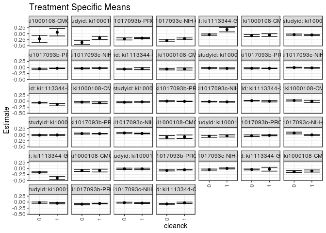

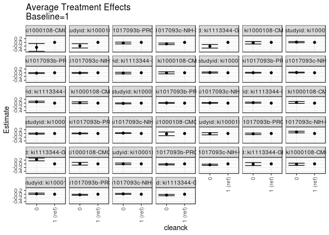

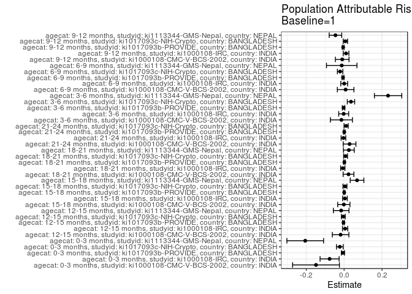

## Results Table

### Parameter: TSM

| agecat | studyid | country | intervention_level | baseline_level | estimate | ci_lower | ci_upper |
| --- | --- | --- | --- | --- | --- | --- | --- |
| 0-3 months | ki1000108-CMC-V-BCS-2002 | INDIA | 1 | NA | 0.0606891 | -0.0912810 | 0.2126593 |
| 0-3 months | ki1000108-CMC-V-BCS-2002 | INDIA | 0 | NA | -0.2090825 | -0.3539703 | -0.0641947 |
| 0-3 months | ki1000108-IRC | INDIA | 1 | NA | -0.1752829 | -0.2470041 | -0.1035617 |
| 0-3 months | ki1000108-IRC | INDIA | 0 | NA | -0.3620917 | -0.4523583 | -0.2718251 |
| 0-3 months | ki1017093b-PROVIDE | BANGLADESH | 1 | NA | -0.1817673 | -0.2007752 | -0.1627593 |
| 0-3 months | ki1017093b-PROVIDE | BANGLADESH | 0 | NA | -0.2152720 | -0.2592787 | -0.1712654 |
| 0-3 months | ki1017093c-NIH-Crypto | BANGLADESH | 1 | NA | -0.2021800 | -0.2306854 | -0.1736745 |
| 0-3 months | ki1017093c-NIH-Crypto | BANGLADESH | 0 | NA | -0.2794228 | -0.3087964 | -0.2500492 |
| 0-3 months | ki1113344-GMS-Nepal | NEPAL | 1 | NA | 0.1731986 | 0.0774761 | 0.2689210 |
| 0-3 months | ki1113344-GMS-Nepal | NEPAL | 0 | NA | -0.0350183 | -0.0621623 | -0.0078743 |
| 3-6 months | ki1000108-CMC-V-BCS-2002 | INDIA | 1 | NA | -0.0836457 | -0.1575218 | -0.0097696 |
| 3-6 months | ki1000108-CMC-V-BCS-2002 | INDIA | 0 | NA | -0.1031850 | -0.1703277 | -0.0360423 |
| 3-6 months | ki1000108-IRC | INDIA | 1 | NA | -0.0494232 | -0.0946683 | -0.0041781 |
| 3-6 months | ki1000108-IRC | INDIA | 0 | NA | -0.0619970 | -0.1023330 | -0.0216609 |
| 3-6 months | ki1017093b-PROVIDE | BANGLADESH | 1 | NA | -0.0241882 | -0.0421840 | -0.0061923 |
| 3-6 months | ki1017093b-PROVIDE | BANGLADESH | 0 | NA | -0.0400926 | -0.0731028 | -0.0070823 |
| 3-6 months | ki1017093c-NIH-Crypto | BANGLADESH | 1 | NA | -0.0059678 | -0.0301865 | 0.0182508 |
| 3-6 months | ki1017093c-NIH-Crypto | BANGLADESH | 0 | NA | 0.0713373 | 0.0352600 | 0.1074146 |
| 3-6 months | ki1113344-GMS-Nepal | NEPAL | 1 | NA | -0.3974205 | -0.4687983 | -0.3260427 |
| 3-6 months | ki1113344-GMS-Nepal | NEPAL | 0 | NA | -0.1617840 | -0.1819009 | -0.1416670 |
| 6-9 months | ki1000108-CMC-V-BCS-2002 | INDIA | 1 | NA | -0.0899474 | -0.1481761 | -0.0317187 |
| 6-9 months | ki1000108-CMC-V-BCS-2002 | INDIA | 0 | NA | -0.0838220 | -0.1287796 | -0.0388643 |
| 6-9 months | ki1000108-IRC | INDIA | 1 | NA | -0.0196387 | -0.0496586 | 0.0103812 |
| 6-9 months | ki1000108-IRC | INDIA | 0 | NA | -0.0176844 | -0.0468101 | 0.0114413 |
| 6-9 months | ki1017093b-PROVIDE | BANGLADESH | 1 | NA | -0.0555724 | -0.0676716 | -0.0434731 |
| 6-9 months | ki1017093b-PROVIDE | BANGLADESH | 0 | NA | -0.0822448 | -0.1065485 | -0.0579411 |
| 6-9 months | ki1017093c-NIH-Crypto | BANGLADESH | 1 | NA | -0.0006854 | -0.0223553 | 0.0209845 |
| 6-9 months | ki1017093c-NIH-Crypto | BANGLADESH | 0 | NA | -0.0499953 | -0.0727071 | -0.0272834 |
| 6-9 months | ki1113344-GMS-Nepal | NEPAL | 1 | NA | -0.0321023 | -0.1124147 | 0.0482102 |
| 6-9 months | ki1113344-GMS-Nepal | NEPAL | 0 | NA | -0.0450512 | -0.0643517 | -0.0257508 |
| 9-12 months | ki1000108-CMC-V-BCS-2002 | INDIA | 1 | NA | -0.1086951 | -0.1523934 | -0.0649967 |
| 9-12 months | ki1000108-CMC-V-BCS-2002 | INDIA | 0 | NA | -0.1300289 | -0.1669011 | -0.0931567 |
| 9-12 months | ki1000108-IRC | INDIA | 1 | NA | -0.0463002 | -0.0701746 | -0.0224258 |
| 9-12 months | ki1000108-IRC | INDIA | 0 | NA | -0.0228739 | -0.0490955 | 0.0033477 |
| 9-12 months | ki1017093b-PROVIDE | BANGLADESH | 1 | NA | -0.0580368 | -0.0704467 | -0.0456270 |
| 9-12 months | ki1017093b-PROVIDE | BANGLADESH | 0 | NA | -0.0857847 | -0.1084491 | -0.0631202 |
| 9-12 months | ki1017093c-NIH-Crypto | BANGLADESH | 1 | NA | -0.0419773 | -0.0593679 | -0.0245866 |
| 9-12 months | ki1017093c-NIH-Crypto | BANGLADESH | 0 | NA | -0.0241365 | -0.0436805 | -0.0045925 |
| 9-12 months | ki1113344-GMS-Nepal | NEPAL | 1 | NA | -0.0314007 | -0.0618148 | -0.0009866 |
| 9-12 months | ki1113344-GMS-Nepal | NEPAL | 0 | NA | -0.0780277 | -0.0930251 | -0.0630303 |
| 12-15 months | ki1000108-CMC-V-BCS-2002 | INDIA | 1 | NA | -0.0526389 | -0.1062545 | 0.0009767 |
| 12-15 months | ki1000108-CMC-V-BCS-2002 | INDIA | 0 | NA | -0.0724908 | -0.1116434 | -0.0333383 |
| 12-15 months | ki1000108-IRC | INDIA | 1 | NA | -0.0498262 | -0.0734482 | -0.0262041 |
| 12-15 months | ki1000108-IRC | INDIA | 0 | NA | -0.0359933 | -0.0600467 | -0.0119399 |
| 12-15 months | ki1017093b-PROVIDE | BANGLADESH | 1 | NA | -0.0374623 | -0.0487043 | -0.0262203 |
| 12-15 months | ki1017093b-PROVIDE | BANGLADESH | 0 | NA | -0.0569956 | -0.0795619 | -0.0344294 |
| 12-15 months | ki1017093c-NIH-Crypto | BANGLADESH | 1 | NA | -0.0322247 | -0.0473481 | -0.0171013 |
| 12-15 months | ki1017093c-NIH-Crypto | BANGLADESH | 0 | NA | -0.0400524 | -0.0576828 | -0.0224220 |
| 12-15 months | ki1113344-GMS-Nepal | NEPAL | 1 | NA | -0.0525575 | -0.0932027 | -0.0119122 |
| 12-15 months | ki1113344-GMS-Nepal | NEPAL | 0 | NA | -0.0684343 | -0.0802563 | -0.0566123 |
| 15-18 months | ki1000108-CMC-V-BCS-2002 | INDIA | 1 | NA | -0.0665246 | -0.1102169 | -0.0228323 |
| 15-18 months | ki1000108-CMC-V-BCS-2002 | INDIA | 0 | NA | -0.0703960 | -0.1028811 | -0.0379109 |
| 15-18 months | ki1000108-IRC | INDIA | 1 | NA | -0.0410568 | -0.0625490 | -0.0195645 |
| 15-18 months | ki1000108-IRC | INDIA | 0 | NA | -0.0310302 | -0.0517781 | -0.0102822 |
| 15-18 months | ki1017093b-PROVIDE | BANGLADESH | 1 | NA | -0.0380146 | -0.0477228 | -0.0283065 |
| 15-18 months | ki1017093b-PROVIDE | BANGLADESH | 0 | NA | -0.0360948 | -0.0563613 | -0.0158283 |
| 15-18 months | ki1017093c-NIH-Crypto | BANGLADESH | 1 | NA | -0.0206888 | -0.0348790 | -0.0064986 |
| 15-18 months | ki1017093c-NIH-Crypto | BANGLADESH | 0 | NA | -0.0081894 | -0.0246029 | 0.0082240 |
| 15-18 months | ki1113344-GMS-Nepal | NEPAL | 1 | NA | -0.1358700 | -0.1700189 | -0.1017211 |
| 15-18 months | ki1113344-GMS-Nepal | NEPAL | 0 | NA | -0.0662360 | -0.0800615 | -0.0524104 |
| 18-21 months | ki1000108-CMC-V-BCS-2002 | INDIA | 1 | NA | -0.0669091 | -0.1031836 | -0.0306345 |
| 18-21 months | ki1000108-CMC-V-BCS-2002 | INDIA | 0 | NA | -0.0442018 | -0.0726179 | -0.0157856 |
| 18-21 months | ki1000108-IRC | INDIA | 1 | NA | -0.0339049 | -0.0521136 | -0.0156962 |
| 18-21 months | ki1000108-IRC | INDIA | 0 | NA | -0.0488518 | -0.0687807 | -0.0289230 |
| 18-21 months | ki1017093b-PROVIDE | BANGLADESH | 1 | NA | -0.0122323 | -0.0210925 | -0.0033721 |
| 18-21 months | ki1017093b-PROVIDE | BANGLADESH | 0 | NA | -0.0031723 | -0.0238940 | 0.0175494 |
| 18-21 months | ki1017093c-NIH-Crypto | BANGLADESH | 1 | NA | -0.0331059 | -0.0467809 | -0.0194310 |
| 18-21 months | ki1017093c-NIH-Crypto | BANGLADESH | 0 | NA | -0.0218803 | -0.0355066 | -0.0082540 |
| 18-21 months | ki1113344-GMS-Nepal | NEPAL | 1 | NA | -0.0084094 | -0.0345648 | 0.0177460 |
| 18-21 months | ki1113344-GMS-Nepal | NEPAL | 0 | NA | 0.0169791 | 0.0040007 | 0.0299576 |
| 21-24 months | ki1000108-CMC-V-BCS-2002 | INDIA | 1 | NA | -0.0110531 | -0.0554488 | 0.0333425 |
| 21-24 months | ki1000108-CMC-V-BCS-2002 | INDIA | 0 | NA | 0.0242248 | 0.0000792 | 0.0483704 |
| 21-24 months | ki1000108-IRC | INDIA | 1 | NA | -0.0106734 | -0.0296557 | 0.0083089 |
| 21-24 months | ki1000108-IRC | INDIA | 0 | NA | -0.0167821 | -0.0365957 | 0.0030315 |
| 21-24 months | ki1017093b-PROVIDE | BANGLADESH | 1 | NA | 0.0454766 | 0.0359161 | 0.0550372 |
| 21-24 months | ki1017093b-PROVIDE | BANGLADESH | 0 | NA | 0.0495556 | 0.0288622 | 0.0702490 |
| 21-24 months | ki1017093c-NIH-Crypto | BANGLADESH | 1 | NA | 0.0527972 | 0.0379569 | 0.0676374 |
| 21-24 months | ki1017093c-NIH-Crypto | BANGLADESH | 0 | NA | 0.0738692 | 0.0609099 | 0.0868285 |

### Parameter: E(Y)

| agecat | studyid | country | intervention_level | baseline_level | estimate | ci_lower | ci_upper |
| --- | --- | --- | --- | --- | --- | --- | --- |
| 0-3 months | ki1000108-CMC-V-BCS-2002 | INDIA | NA | NA | -0.0878386 | -0.1937874 | 0.0181102 |
| 0-3 months | ki1000108-IRC | INDIA | NA | NA | -0.2520229 | -0.3078384 | -0.1962074 |
| 0-3 months | ki1017093b-PROVIDE | BANGLADESH | NA | NA | -0.1880402 | -0.2054115 | -0.1706689 |
| 0-3 months | ki1017093c-NIH-Crypto | BANGLADESH | NA | NA | -0.2248633 | -0.2444011 | -0.2053256 |
| 0-3 months | ki1113344-GMS-Nepal | NEPAL | NA | NA | -0.0323024 | -0.0589635 | -0.0056413 |
| 3-6 months | ki1000108-CMC-V-BCS-2002 | INDIA | NA | NA | -0.0979615 | -0.1455947 | -0.0503283 |
| 3-6 months | ki1000108-IRC | INDIA | NA | NA | -0.0517747 | -0.0822588 | -0.0212906 |
| 3-6 months | ki1017093b-PROVIDE | BANGLADESH | NA | NA | -0.0269625 | -0.0428628 | -0.0110622 |
| 3-6 months | ki1017093c-NIH-Crypto | BANGLADESH | NA | NA | 0.0302642 | 0.0105575 | 0.0499710 |
| 3-6 months | ki1113344-GMS-Nepal | NEPAL | NA | NA | -0.1651184 | -0.1849912 | -0.1452456 |
| 6-9 months | ki1000108-CMC-V-BCS-2002 | INDIA | NA | NA | -0.0819656 | -0.1161677 | -0.0477635 |
| 6-9 months | ki1000108-IRC | INDIA | NA | NA | -0.0191453 | -0.0403295 | 0.0020389 |
| 6-9 months | ki1017093b-PROVIDE | BANGLADESH | NA | NA | -0.0614264 | -0.0722690 | -0.0505838 |
| 6-9 months | ki1017093c-NIH-Crypto | BANGLADESH | NA | NA | -0.0219170 | -0.0369369 | -0.0068971 |
| 6-9 months | ki1113344-GMS-Nepal | NEPAL | NA | NA | -0.0448120 | -0.0637374 | -0.0258865 |
| 9-12 months | ki1000108-CMC-V-BCS-2002 | INDIA | NA | NA | -0.1188156 | -0.1473352 | -0.0902961 |
| 9-12 months | ki1000108-IRC | INDIA | NA | NA | -0.0361183 | -0.0532692 | -0.0189675 |
| 9-12 months | ki1017093b-PROVIDE | BANGLADESH | NA | NA | -0.0630470 | -0.0740183 | -0.0520757 |
| 9-12 months | ki1017093c-NIH-Crypto | BANGLADESH | NA | NA | -0.0352217 | -0.0477064 | -0.0227371 |
| 9-12 months | ki1113344-GMS-Nepal | NEPAL | NA | NA | -0.0771479 | -0.0918027 | -0.0624932 |
| 12-15 months | ki1000108-CMC-V-BCS-2002 | INDIA | NA | NA | -0.0712336 | -0.0991765 | -0.0432907 |
| 12-15 months | ki1000108-IRC | INDIA | NA | NA | -0.0446142 | -0.0616724 | -0.0275560 |
| 12-15 months | ki1017093b-PROVIDE | BANGLADESH | NA | NA | -0.0409107 | -0.0510053 | -0.0308161 |
| 12-15 months | ki1017093c-NIH-Crypto | BANGLADESH | NA | NA | -0.0365229 | -0.0475564 | -0.0254894 |
| 12-15 months | ki1113344-GMS-Nepal | NEPAL | NA | NA | -0.0681340 | -0.0797070 | -0.0565610 |
| 15-18 months | ki1000108-CMC-V-BCS-2002 | INDIA | NA | NA | -0.0680871 | -0.0915055 | -0.0446686 |
| 15-18 months | ki1000108-IRC | INDIA | NA | NA | -0.0367739 | -0.0516890 | -0.0218588 |
| 15-18 months | ki1017093b-PROVIDE | BANGLADESH | NA | NA | -0.0376437 | -0.0463882 | -0.0288992 |
| 15-18 months | ki1017093c-NIH-Crypto | BANGLADESH | NA | NA | -0.0162904 | -0.0258853 | -0.0066955 |
| 15-18 months | ki1113344-GMS-Nepal | NEPAL | NA | NA | -0.0675196 | -0.0810553 | -0.0539839 |
| 18-21 months | ki1000108-CMC-V-BCS-2002 | INDIA | NA | NA | -0.0437658 | -0.0661084 | -0.0214232 |
| 18-21 months | ki1000108-IRC | INDIA | NA | NA | -0.0410011 | -0.0544100 | -0.0275923 |
| 18-21 months | ki1017093b-PROVIDE | BANGLADESH | NA | NA | -0.0109399 | -0.0190984 | -0.0027814 |
| 18-21 months | ki1017093c-NIH-Crypto | BANGLADESH | NA | NA | -0.0253964 | -0.0344213 | -0.0163714 |
| 18-21 months | ki1113344-GMS-Nepal | NEPAL | NA | NA | 0.0165414 | 0.0038665 | 0.0292163 |
| 21-24 months | ki1000108-CMC-V-BCS-2002 | INDIA | NA | NA | 0.0177011 | -0.0032847 | 0.0386869 |
| 21-24 months | ki1000108-IRC | INDIA | NA | NA | -0.0141818 | -0.0280342 | -0.0003294 |
| 21-24 months | ki1017093b-PROVIDE | BANGLADESH | NA | NA | 0.0462342 | 0.0375872 | 0.0548812 |
| 21-24 months | ki1017093c-NIH-Crypto | BANGLADESH | NA | NA | 0.0634123 | 0.0544343 | 0.0723903 |

### Parameter: ATE

| agecat | studyid | country | intervention_level | baseline_level | estimate | ci_lower | ci_upper |
| --- | --- | --- | --- | --- | --- | --- | --- |
| 0-3 months | ki1000108-CMC-V-BCS-2002 | INDIA | 1 | 1 | 0.0000000 | 0.0000000 | 0.0000000 |
| 0-3 months | ki1000108-CMC-V-BCS-2002 | INDIA | 0 | 1 | -0.2697716 | -0.4809379 | -0.0586053 |
| 0-3 months | ki1000108-IRC | INDIA | 1 | 1 | 0.0000000 | 0.0000000 | 0.0000000 |
| 0-3 months | ki1000108-IRC | INDIA | 0 | 1 | -0.1868088 | -0.3022408 | -0.0713768 |
| 0-3 months | ki1017093b-PROVIDE | BANGLADESH | 1 | 1 | 0.0000000 | 0.0000000 | 0.0000000 |
| 0-3 months | ki1017093b-PROVIDE | BANGLADESH | 0 | 1 | -0.0335048 | -0.0817088 | 0.0146993 |
| 0-3 months | ki1017093c-NIH-Crypto | BANGLADESH | 1 | 1 | 0.0000000 | 0.0000000 | 0.0000000 |
| 0-3 months | ki1017093c-NIH-Crypto | BANGLADESH | 0 | 1 | -0.0772428 | -0.1182827 | -0.0362030 |
| 0-3 months | ki1113344-GMS-Nepal | NEPAL | 1 | 1 | 0.0000000 | 0.0000000 | 0.0000000 |
| 0-3 months | ki1113344-GMS-Nepal | NEPAL | 0 | 1 | -0.2082168 | -0.3077134 | -0.1087202 |
| 3-6 months | ki1000108-CMC-V-BCS-2002 | INDIA | 1 | 1 | 0.0000000 | 0.0000000 | 0.0000000 |
| 3-6 months | ki1000108-CMC-V-BCS-2002 | INDIA | 0 | 1 | -0.0195393 | -0.1194732 | 0.0803946 |
| 3-6 months | ki1000108-IRC | INDIA | 1 | 1 | 0.0000000 | 0.0000000 | 0.0000000 |
| 3-6 months | ki1000108-IRC | INDIA | 0 | 1 | -0.0125738 | -0.0734320 | 0.0482844 |
| 3-6 months | ki1017093b-PROVIDE | BANGLADESH | 1 | 1 | 0.0000000 | 0.0000000 | 0.0000000 |
| 3-6 months | ki1017093b-PROVIDE | BANGLADESH | 0 | 1 | -0.0159044 | -0.0535211 | 0.0217123 |
| 3-6 months | ki1017093c-NIH-Crypto | BANGLADESH | 1 | 1 | 0.0000000 | 0.0000000 | 0.0000000 |
| 3-6 months | ki1017093c-NIH-Crypto | BANGLADESH | 0 | 1 | 0.0773051 | 0.0336459 | 0.1209643 |
| 3-6 months | ki1113344-GMS-Nepal | NEPAL | 1 | 1 | 0.0000000 | 0.0000000 | 0.0000000 |
| 3-6 months | ki1113344-GMS-Nepal | NEPAL | 0 | 1 | 0.2356365 | 0.1614780 | 0.3097950 |
| 6-9 months | ki1000108-CMC-V-BCS-2002 | INDIA | 1 | 1 | 0.0000000 | 0.0000000 | 0.0000000 |
| 6-9 months | ki1000108-CMC-V-BCS-2002 | INDIA | 0 | 1 | 0.0061255 | -0.0675257 | 0.0797766 |
| 6-9 months | ki1000108-IRC | INDIA | 1 | 1 | 0.0000000 | 0.0000000 | 0.0000000 |
| 6-9 months | ki1000108-IRC | INDIA | 0 | 1 | 0.0019543 | -0.0399863 | 0.0438949 |
| 6-9 months | ki1017093b-PROVIDE | BANGLADESH | 1 | 1 | 0.0000000 | 0.0000000 | 0.0000000 |
| 6-9 months | ki1017093b-PROVIDE | BANGLADESH | 0 | 1 | -0.0266724 | -0.0539213 | 0.0005765 |
| 6-9 months | ki1017093c-NIH-Crypto | BANGLADESH | 1 | 1 | 0.0000000 | 0.0000000 | 0.0000000 |
| 6-9 months | ki1017093c-NIH-Crypto | BANGLADESH | 0 | 1 | -0.0493099 | -0.0807020 | -0.0179178 |
| 6-9 months | ki1113344-GMS-Nepal | NEPAL | 1 | 1 | 0.0000000 | 0.0000000 | 0.0000000 |
| 6-9 months | ki1113344-GMS-Nepal | NEPAL | 0 | 1 | -0.0129489 | -0.0955480 | 0.0696501 |
| 9-12 months | ki1000108-CMC-V-BCS-2002 | INDIA | 1 | 1 | 0.0000000 | 0.0000000 | 0.0000000 |
| 9-12 months | ki1000108-CMC-V-BCS-2002 | INDIA | 0 | 1 | -0.0213338 | -0.0788683 | 0.0362006 |
| 9-12 months | ki1000108-IRC | INDIA | 1 | 1 | 0.0000000 | 0.0000000 | 0.0000000 |
| 9-12 months | ki1000108-IRC | INDIA | 0 | 1 | 0.0234263 | -0.0119269 | 0.0587796 |
| 9-12 months | ki1017093b-PROVIDE | BANGLADESH | 1 | 1 | 0.0000000 | 0.0000000 | 0.0000000 |
| 9-12 months | ki1017093b-PROVIDE | BANGLADESH | 0 | 1 | -0.0277478 | -0.0536285 | -0.0018672 |
| 9-12 months | ki1017093c-NIH-Crypto | BANGLADESH | 1 | 1 | 0.0000000 | 0.0000000 | 0.0000000 |
| 9-12 months | ki1017093c-NIH-Crypto | BANGLADESH | 0 | 1 | 0.0178408 | -0.0083079 | 0.0439896 |
| 9-12 months | ki1113344-GMS-Nepal | NEPAL | 1 | 1 | 0.0000000 | 0.0000000 | 0.0000000 |
| 9-12 months | ki1113344-GMS-Nepal | NEPAL | 0 | 1 | -0.0466270 | -0.0805378 | -0.0127163 |
| 12-15 months | ki1000108-CMC-V-BCS-2002 | INDIA | 1 | 1 | 0.0000000 | 0.0000000 | 0.0000000 |
| 12-15 months | ki1000108-CMC-V-BCS-2002 | INDIA | 0 | 1 | -0.0198519 | -0.0865715 | 0.0468676 |
| 12-15 months | ki1000108-IRC | INDIA | 1 | 1 | 0.0000000 | 0.0000000 | 0.0000000 |
| 12-15 months | ki1000108-IRC | INDIA | 0 | 1 | 0.0138329 | -0.0198149 | 0.0474806 |
| 12-15 months | ki1017093b-PROVIDE | BANGLADESH | 1 | 1 | 0.0000000 | 0.0000000 | 0.0000000 |
| 12-15 months | ki1017093b-PROVIDE | BANGLADESH | 0 | 1 | -0.0195333 | -0.0447355 | 0.0056688 |
| 12-15 months | ki1017093c-NIH-Crypto | BANGLADESH | 1 | 1 | 0.0000000 | 0.0000000 | 0.0000000 |
| 12-15 months | ki1017093c-NIH-Crypto | BANGLADESH | 0 | 1 | -0.0078277 | -0.0310588 | 0.0154035 |
| 12-15 months | ki1113344-GMS-Nepal | NEPAL | 1 | 1 | 0.0000000 | 0.0000000 | 0.0000000 |
| 12-15 months | ki1113344-GMS-Nepal | NEPAL | 0 | 1 | -0.0158768 | -0.0582064 | 0.0264528 |
| 15-18 months | ki1000108-CMC-V-BCS-2002 | INDIA | 1 | 1 | 0.0000000 | 0.0000000 | 0.0000000 |
| 15-18 months | ki1000108-CMC-V-BCS-2002 | INDIA | 0 | 1 | -0.0038715 | -0.0588335 | 0.0510906 |
| 15-18 months | ki1000108-IRC | INDIA | 1 | 1 | 0.0000000 | 0.0000000 | 0.0000000 |
| 15-18 months | ki1000108-IRC | INDIA | 0 | 1 | 0.0100266 | -0.0203985 | 0.0404516 |
| 15-18 months | ki1017093b-PROVIDE | BANGLADESH | 1 | 1 | 0.0000000 | 0.0000000 | 0.0000000 |
| 15-18 months | ki1017093b-PROVIDE | BANGLADESH | 0 | 1 | 0.0019199 | -0.0205912 | 0.0244309 |
| 15-18 months | ki1017093c-NIH-Crypto | BANGLADESH | 1 | 1 | 0.0000000 | 0.0000000 | 0.0000000 |
| 15-18 months | ki1017093c-NIH-Crypto | BANGLADESH | 0 | 1 | 0.0124993 | -0.0092252 | 0.0342239 |
| 15-18 months | ki1113344-GMS-Nepal | NEPAL | 1 | 1 | 0.0000000 | 0.0000000 | 0.0000000 |
| 15-18 months | ki1113344-GMS-Nepal | NEPAL | 0 | 1 | 0.0696340 | 0.0327926 | 0.1064755 |
| 18-21 months | ki1000108-CMC-V-BCS-2002 | INDIA | 1 | 1 | 0.0000000 | 0.0000000 | 0.0000000 |
| 18-21 months | ki1000108-CMC-V-BCS-2002 | INDIA | 0 | 1 | 0.0227073 | -0.0236044 | 0.0690190 |
| 18-21 months | ki1000108-IRC | INDIA | 1 | 1 | 0.0000000 | 0.0000000 | 0.0000000 |
| 18-21 months | ki1000108-IRC | INDIA | 0 | 1 | -0.0149469 | -0.0420966 | 0.0122027 |
| 18-21 months | ki1017093b-PROVIDE | BANGLADESH | 1 | 1 | 0.0000000 | 0.0000000 | 0.0000000 |
| 18-21 months | ki1017093b-PROVIDE | BANGLADESH | 0 | 1 | 0.0090600 | -0.0135068 | 0.0316267 |
| 18-21 months | ki1017093c-NIH-Crypto | BANGLADESH | 1 | 1 | 0.0000000 | 0.0000000 | 0.0000000 |
| 18-21 months | ki1017093c-NIH-Crypto | BANGLADESH | 0 | 1 | 0.0112256 | -0.0081559 | 0.0306071 |
| 18-21 months | ki1113344-GMS-Nepal | NEPAL | 1 | 1 | 0.0000000 | 0.0000000 | 0.0000000 |
| 18-21 months | ki1113344-GMS-Nepal | NEPAL | 0 | 1 | 0.0253885 | -0.0038098 | 0.0545869 |
| 21-24 months | ki1000108-CMC-V-BCS-2002 | INDIA | 1 | 1 | 0.0000000 | 0.0000000 | 0.0000000 |
| 21-24 months | ki1000108-CMC-V-BCS-2002 | INDIA | 0 | 1 | 0.0352780 | -0.0152515 | 0.0858075 |
| 21-24 months | ki1000108-IRC | INDIA | 1 | 1 | 0.0000000 | 0.0000000 | 0.0000000 |
| 21-24 months | ki1000108-IRC | INDIA | 0 | 1 | -0.0061087 | -0.0335918 | 0.0213744 |
| 21-24 months | ki1017093b-PROVIDE | BANGLADESH | 1 | 1 | 0.0000000 | 0.0000000 | 0.0000000 |
| 21-24 months | ki1017093b-PROVIDE | BANGLADESH | 0 | 1 | 0.0040790 | -0.0187284 | 0.0268864 |
| 21-24 months | ki1017093c-NIH-Crypto | BANGLADESH | 1 | 1 | 0.0000000 | 0.0000000 | 0.0000000 |
| 21-24 months | ki1017093c-NIH-Crypto | BANGLADESH | 0 | 1 | 0.0210721 | 0.0013255 | 0.0408187 |

### Parameter: PAR

| agecat | studyid | country | intervention_level | baseline_level | estimate | ci_lower | ci_upper |
| --- | --- | --- | --- | --- | --- | --- | --- |
| 0-3 months | ki1000108-CMC-V-BCS-2002 | INDIA | 1 | NA | -0.1485277 | -0.2721447 | -0.0249107 |
| 0-3 months | ki1000108-IRC | INDIA | 1 | NA | -0.0767401 | -0.1270779 | -0.0264022 |
| 0-3 months | ki1017093b-PROVIDE | BANGLADESH | 1 | NA | -0.0062729 | -0.0147304 | 0.0021845 |
| 0-3 months | ki1017093c-NIH-Crypto | BANGLADESH | 1 | NA | -0.0226833 | -0.0403518 | -0.0050149 |
| 0-3 months | ki1113344-GMS-Nepal | NEPAL | 1 | NA | -0.2055009 | -0.3025342 | -0.1084677 |
| 3-6 months | ki1000108-CMC-V-BCS-2002 | INDIA | 1 | NA | -0.0143158 | -0.0724827 | 0.0438511 |
| 3-6 months | ki1000108-IRC | INDIA | 1 | NA | -0.0023516 | -0.0286327 | 0.0239296 |
| 3-6 months | ki1017093b-PROVIDE | BANGLADESH | 1 | NA | -0.0027743 | -0.0093795 | 0.0038308 |
| 3-6 months | ki1017093c-NIH-Crypto | BANGLADESH | 1 | NA | 0.0362321 | 0.0167777 | 0.0556865 |
| 3-6 months | ki1113344-GMS-Nepal | NEPAL | 1 | NA | 0.2323021 | 0.1599489 | 0.3046552 |
| 6-9 months | ki1000108-CMC-V-BCS-2002 | INDIA | 1 | NA | 0.0079818 | -0.0359116 | 0.0518752 |
| 6-9 months | ki1000108-IRC | INDIA | 1 | NA | 0.0004934 | -0.0175908 | 0.0185776 |
| 6-9 months | ki1017093b-PROVIDE | BANGLADESH | 1 | NA | -0.0058540 | -0.0109778 | -0.0007303 |
| 6-9 months | ki1017093c-NIH-Crypto | BANGLADESH | 1 | NA | -0.0212316 | -0.0355425 | -0.0069207 |
| 6-9 months | ki1113344-GMS-Nepal | NEPAL | 1 | NA | -0.0127097 | -0.0932439 | 0.0678245 |
| 9-12 months | ki1000108-CMC-V-BCS-2002 | INDIA | 1 | NA | -0.0101205 | -0.0462412 | 0.0260001 |
| 9-12 months | ki1000108-IRC | INDIA | 1 | NA | 0.0101819 | -0.0047822 | 0.0251459 |
| 9-12 months | ki1017093b-PROVIDE | BANGLADESH | 1 | NA | -0.0050102 | -0.0096796 | -0.0003407 |
| 9-12 months | ki1017093c-NIH-Crypto | BANGLADESH | 1 | NA | 0.0067556 | -0.0048584 | 0.0183695 |
| 9-12 months | ki1113344-GMS-Nepal | NEPAL | 1 | NA | -0.0457472 | -0.0788158 | -0.0126787 |
| 12-15 months | ki1000108-CMC-V-BCS-2002 | INDIA | 1 | NA | -0.0185947 | -0.0623427 | 0.0251532 |
| 12-15 months | ki1000108-IRC | INDIA | 1 | NA | 0.0052120 | -0.0087697 | 0.0191936 |
| 12-15 months | ki1017093b-PROVIDE | BANGLADESH | 1 | NA | -0.0034484 | -0.0077680 | 0.0008712 |
| 12-15 months | ki1017093c-NIH-Crypto | BANGLADESH | 1 | NA | -0.0042982 | -0.0145092 | 0.0059128 |
| 12-15 months | ki1113344-GMS-Nepal | NEPAL | 1 | NA | -0.0155766 | -0.0568484 | 0.0256953 |
| 15-18 months | ki1000108-CMC-V-BCS-2002 | INDIA | 1 | NA | -0.0015625 | -0.0340681 | 0.0309431 |
| 15-18 months | ki1000108-IRC | INDIA | 1 | NA | 0.0042829 | -0.0081547 | 0.0167205 |
| 15-18 months | ki1017093b-PROVIDE | BANGLADESH | 1 | NA | 0.0003709 | -0.0035530 | 0.0042948 |
| 15-18 months | ki1017093c-NIH-Crypto | BANGLADESH | 1 | NA | 0.0043984 | -0.0061210 | 0.0149177 |
| 15-18 months | ki1113344-GMS-Nepal | NEPAL | 1 | NA | 0.0683504 | 0.0324192 | 0.1042817 |
| 18-21 months | ki1000108-CMC-V-BCS-2002 | INDIA | 1 | NA | 0.0231433 | -0.0053697 | 0.0516562 |
| 18-21 months | ki1000108-IRC | INDIA | 1 | NA | -0.0070962 | -0.0185627 | 0.0043703 |
| 18-21 months | ki1017093b-PROVIDE | BANGLADESH | 1 | NA | 0.0012924 | -0.0028989 | 0.0054836 |
| 18-21 months | ki1017093c-NIH-Crypto | BANGLADESH | 1 | NA | 0.0077095 | -0.0025751 | 0.0179942 |
| 18-21 months | ki1113344-GMS-Nepal | NEPAL | 1 | NA | 0.0249508 | -0.0035194 | 0.0534210 |
| 21-24 months | ki1000108-CMC-V-BCS-2002 | INDIA | 1 | NA | 0.0287543 | -0.0049469 | 0.0624554 |
| 21-24 months | ki1000108-IRC | INDIA | 1 | NA | -0.0035084 | -0.0158844 | 0.0088676 |
| 21-24 months | ki1017093b-PROVIDE | BANGLADESH | 1 | NA | 0.0007576 | -0.0032469 | 0.0047621 |
| 21-24 months | ki1017093c-NIH-Crypto | BANGLADESH | 1 | NA | 0.0106151 | -0.0004831 | 0.0217134 |